# Project: Investigate a Dataset (TMDb_Movies Dataset)

- Introduction
- Data Wrangling
- Exploratory Data Analysis
- Conclusions

## Introduction

> To complete my Data Analysis project, TMDb movies dataset is used.

> This data set contains information about 10 thousand movies collected from The Movie Database (TMDb), including user ratings and revenue. It consist of 21 columns such as imdb_id, revenue, budget, vote_count etc.

#### Question that can analyised from this data set

1. General questions about the dataset.  
   1.1 Which movie earns the most and least profit?  
   1.2 Which movie had the greatest and least budget?  
   1.3 Which movie had the greatest and least revenue?  
   1.4 What is the average runtime of all movies?
2. Detailed analysis about the dataset.  
   2.1 How do budgets correlate with revenues? Do higher budget movies have higher revenue?  
   2.2 How do ratings correlate with commercial success (profits)?

```python
# Use this cell to set up import statements for all of the packages that you
#   plan to use.

# Remember to include a 'magic word' so that your visualizations are plotted
#   inline with the notebook. See this page for more:
#   http://ipython.readthedocs.io/en/stable/interactive/magics.html

import pandas as pd
import numpy as np
import csv
from datetime import datetime
import matplotlib.pyplot as plt
% matplotlib inline
```

## Data Wrangling

> After observing the dataset and proposed questions for the analysis we will be keeping only relevent data deleting the unsued data so that we can make our calculation easy and understandable.

### General Properties

```python
# Load your data and print out a few lines. Perform operations to inspect data
#   types and look for instances of missing or possibly errant data.
tmdb_data = pd.read_csv('Project/tmdb_movies_data.csv')

tmdb_data.head()
```

|  | id | imdb_id | popularity | budget | revenue | original_title | cast | homepage | director | tagline | ... | overview | runtime | genres | production_companies | release_date | vote_count | vote_average | release_year | budget_adj | revenue_adj |
| --- | --- | --- | --- | --- | --- | --- | --- | --- | --- | --- | --- | --- | --- | --- | --- | --- | --- | --- | --- | --- | --- |
| 0 | 135397 | tt0369610 | 32.985763 | 150000000 | 1513528810 | Jurassic World | Chris Pratt\|Bryce Dallas Howard\|Irrfan Khan\|Vi... | http://www.jurassicworld.com/ | Colin Trevorrow | The park is open. | ... | Twenty-two years after the events of Jurassic ... | 124 | Action\|Adventure\|Science Fiction\|Thriller | Universal Studios\|Amblin Entertainment\|Legenda... | 6/9/2015 | 5562 | 6.5 | 2015 | 137999939.3 | 1.392446e+09 |
| 1 | 76341 | tt1392190 | 28.419936 | 150000000 | 378436354 | Mad Max: Fury Road | Tom Hardy\|Charlize Theron\|Hugh Keays-Byrne\|Nic... | http://www.madmaxmovie.com/ | George Miller | What a Lovely Day. | ... | An apocalyptic story set in the furthest reach... | 120 | Action\|Adventure\|Science Fiction\|Thriller | Village Roadshow Pictures\|Kennedy Miller Produ... | 5/13/2015 | 6185 | 7.1 | 2015 | 137999939.3 | 3.481613e+08 |
| 2 | 262500 | tt2908446 | 13.112507 | 110000000 | 295238201 | Insurgent | Shailene Woodley\|Theo James\|Kate Winslet\|Ansel... | http://www.thedivergentseries.movie/#insurgent | Robert Schwentke | One Choice Can Destroy You | ... | Beatrice Prior must confront her inner demons ... | 119 | Adventure\|Science Fiction\|Thriller | Summit Entertainment\|Mandeville Films\|Red Wago... | 3/18/2015 | 2480 | 6.3 | 2015 | 101199955.5 | 2.716190e+08 |
| 3 | 140607 | tt2488496 | 11.173104 | 200000000 | 2068178225 | Star Wars: The Force Awakens | Harrison Ford\|Mark Hamill\|Carrie Fisher\|Adam D... | http://www.starwars.com/films/star-wars-episod... | J.J. Abrams | Every generation has a story. | ... | Thirty years after defeating the Galactic Empi... | 136 | Action\|Adventure\|Science Fiction\|Fantasy | Lucasfilm\|Truenorth Productions\|Bad Robot | 12/15/2015 | 5292 | 7.5 | 2015 | 183999919.0 | 1.902723e+09 |
| 4 | 168259 | tt2820852 | 9.335014 | 190000000 | 1506249360 | Furious 7 | Vin Diesel\|Paul Walker\|Jason Statham\|Michelle ... | http://www.furious7.com/ | James Wan | Vengeance Hits Home | ... | Deckard Shaw seeks revenge against Dominic Tor... | 137 | Action\|Crime\|Thriller | Universal Pictures\|Original Film\|Media Rights ... | 4/1/2015 | 2947 | 7.3 | 2015 | 174799923.1 | 1.385749e+09 |

5 rows × 21 columns

```python
#columns with null values
tmdb_data.columns[tmdb_data.isnull().any()].tolist()
```

```
['imdb_id',
 'cast',
 'homepage',
 'director',
 'tagline',
 'keywords',
 'overview',
 'genres',
 'production_companies']
```

```python
#rows with null values
tmdb_data.isnull().any(axis=1).sum()
```

```
8874
```

```python
#duplicate row count in the dataset
sum(tmdb_data.duplicated())
```

```
1
```

```python
#Print duplicate row
for i,v in tmdb_data.duplicated().iteritems():
    if (v):
        print (tmdb_data.loc[i])
```

```
id                                                                  42194
imdb_id                                                         tt0411951
popularity                                                        0.59643
budget                                                           30000000
revenue                                                            967000
original_title                                                     TEKKEN
cast                    Jon Foo|Kelly Overton|Cary-Hiroyuki Tagawa|Ian...
homepage                                                              NaN
director                                                 Dwight H. Little
tagline                                               Survival is no game
keywords                martial arts|dystopia|based on video game|mart...
overview                In the year of 2039, after World Wars destroy ...
runtime                                                                92
genres                        Crime|Drama|Action|Thriller|Science Fiction
production_companies                               Namco|Light Song Films
release_date                                                    3/20/2010
vote_count                                                            110
vote_average                                                            5
release_year                                                         2010
budget_adj                                                          3e+07
revenue_adj                                                        967000
Name: 2090, dtype: object
```

### Data Cleaning

Before answering the above questions we need a clean dataset which has columns and rows we need for calculations.

First, lets clean up the columns. We will only keep the columns we need and remove the rest of them.

Columns to delete - id, imdb_id, popularity, budget_adj, revenue_adj, homepage, keywords, overview, production_companies, vote_count and vote_average.

```python
#lets give a list of movies that needs to be deleted
del_col = [ 'id', 'imdb_id', 'popularity', 'budget_adj', 'revenue_adj', 'homepage', 'keywords', 'overview', 'production_companies', 'vote_count', 'vote_average']


#deleting the columns from the database
movie_data = tmdb_data.drop(del_col, 1)
#now take a look at this new dataset
movie_data.head(3)
```

|  | budget | revenue | original_title | cast | director | tagline | runtime | genres | release_date | release_year |
| --- | --- | --- | --- | --- | --- | --- | --- | --- | --- | --- |
| 0 | 150000000 | 1513528810 | Jurassic World | Chris Pratt\|Bryce Dallas Howard\|Irrfan Khan\|Vi... | Colin Trevorrow | The park is open. | 124 | Action\|Adventure\|Science Fiction\|Thriller | 6/9/2015 | 2015 |
| 1 | 150000000 | 378436354 | Mad Max: Fury Road | Tom Hardy\|Charlize Theron\|Hugh Keays-Byrne\|Nic... | George Miller | What a Lovely Day. | 120 | Action\|Adventure\|Science Fiction\|Thriller | 5/13/2015 | 2015 |
| 2 | 110000000 | 295238201 | Insurgent | Shailene Woodley\|Theo James\|Kate Winslet\|Ansel... | Robert Schwentke | One Choice Can Destroy You | 119 | Adventure\|Science Fiction\|Thriller | 3/18/2015 | 2015 |

```python
# After discussing the structure of the data and any problems that need to be
#   cleaned, perform those cleaning steps in the second part of this section.
import numpy as np
from matplotlib import pyplot as plt
import seaborn as sns

#this variable will store the database of tmdb movies into a dataframe
movie_data = pd.read_csv('Project/tmdb_movies_data.csv')

rows, col = movie_data.shape
#since 'rows' includes count of a header, we need to remove its count.
print('We have {} total entries of movies and {} columns/features of it.'.format(rows-1, col))
```

```
We have 10865 total entries of movies and 21 columns/features of it.
```

```python
#drop duplicate rows but keep the first one
movie_data.drop_duplicates(keep = 'first', inplace = True)

rows, col = movie_data.shape
print('We now have {} total entries of movies and {} columns/features of it.'.format(rows-1, col))
```

```
We now have 10864 total entries of movies and 21 columns/features of it.
```

```python
#list of column names that needs to be checked
check_row = ['budget', 'revenue']

#this will replace the value of '0' to NaN of columns given in the list
movie_data[check_row] = movie_data[check_row].replace(0, np.NaN)

#now we will drop any row which has NaN values in any of the column of the list (check_row)
movie_data.dropna(subset = check_row, inplace = True)

rows, col = movie_data.shape
print('After cleaning, we now have only {} entries of movies.'.format(rows-1))
```

```
After cleaning, we now have only 3853 entries of movies.
```

```python
#replacing 0 with NaN of runtime column of the dataframe#replac
movie_data['runtime'] = movie_data['runtime'].replace(0, np.NaN)

#calling the column which need to be formatted in datetime and storing those values in them
movie_data.release_date = pd.to_datetime(movie_data['release_date'])

#showing the dataset
movie_data.head(2)
```

[output not shown]

## Exploratory Data Analysis

> **Tip**: Now that you've trimmed and cleaned your data, you're ready to move on to exploration. Compute statistics and create visualizations with the goal of addressing the research questions that you posed in the Introduction section. It is recommended that you be systematic with your approach. Look at one variable at a time, and then follow it up by looking at relationships between variables.

### Research Question 1 (General questions)

##### Which movie earns the most and least profit?

```python
#rename function renames the columns, the key as being the old name and its value new name of it in form of dictionary.
movie_data.rename(columns = {'budget' : 'budget_(in_US-Dollars)', 'revenue' : 'revenue_(in_US-Dollars)'}, inplace = True)
#To calculate profit of each movie, we need to substract the budget from the revenue of each movie
movie_data.insert(2, 'profit_(in_US_Dollars)', movie_data['revenue_(in_US-Dollars)'] - movie_data['budget_(in_US-Dollars)'])

#for just in case situations or for convenience, we change the data type to int
movie_data['profit_(in_US_Dollars)'] = movie_data['profit_(in_US_Dollars)'].apply(np.int64)
def highest_lowest(column_name):

    #highest
    #taking the index value of the highest number in profit column
    highest_id = movie_data[column_name].idxmax()
    #calling by index number,storing that row info to a variable
    highest_details = pd.DataFrame(movie_data.loc[highest_id])

    #lowest
    #same processing as above
    lowest_id = movie_data[column_name].idxmin()
    lowest_details = pd.DataFrame(movie_data.loc[lowest_id])

    #concatenating two dataframes
    two_in_one_data = pd.concat([highest_details, lowest_details], axis = 1)

    return two_in_one_data

#calling the function and passing the argument
highest_lowest('profit_(in_US_Dollars)')
```

[output not shown]

The column names for the dataframes above are the index number. The first column shows the highest profit made by a movie and second column shows the highest in loss movie in this dataset.

As we can see the Directed by James Cameron, Avatar film has the highest profit in all, making over $2.5B in profit in this dataset. May be the highest till now of entire human race but we can't say for sure as this dataset doesn't have all the films released till date.

And the most in loss movie in this dataset is The Warriors Way. Going in loss by more than $400M was directed by Singmoo Lee.

#### Which movie had the greatest and least budget?

```python
#as our calculations seems to be same as previous one for different column, lets call the function by passing desired argument#as our

highest_lowest('budget_(in_US-Dollars)')
```

|  | 2244 | 2618 |
| --- | --- | --- |
| budget_(in_US-Dollars) | 4.25e+08 | 1 |
| revenue_(in_US-Dollars) | 1.10876e+07 | 100 |
| profit_(in_US_Dollars) | -413912431 | 99 |
| original_title | The Warrior's Way | Lost & Found |
| cast | Kate Bosworth\|Jang Dong-gun\|Geoffrey Rush\|Dann... | David Spade\|Sophie Marceau\|Ever Carradine\|Step... |
| director | Sngmoo Lee | Jeff Pollack |
| tagline | Assassin. Hero. Legend. | A comedy about a guy who would do anything to ... |
| runtime | 100 | 95 |
| genres | Adventure\|Fantasy\|Action\|Western\|Thriller | Comedy\|Romance |
| release_date | 2010-12-02 00:00:00 | 1999-04-23 00:00:00 |
| release_year | 2010 | 1999 |

we can see that The Warriors Way had the highest budget of all movies in the dataset of about $425M. This same movie also had the highest loss. So it makes sense that having the highest budget in all makes the film more harder to have higher revenues and earn more profits.

And the least budget of all, the Lost & Found movie of dollar1 has made me thinking how can a movie with 95 min of runtime managed with such low budget! Also making revenue of dollar100 and earning a profit $99, this may be a local movie release. Because it's kind of impossible to have such low budget and earning low revenues if it has released internationally.

#### Which movie had the greatest and least revenue?

```python
#again, we will call our function!
highest_lowest('revenue_(in_US-Dollars)')
```

|  | 1386 | 5067 |
| --- | --- | --- |
| budget_(in_US-Dollars) | 2.37e+08 | 6e+06 |
| revenue_(in_US-Dollars) | 2.78151e+09 | 2 |
| profit_(in_US_Dollars) | 2544505847 | -5999998 |
| original_title | Avatar | Shattered Glass |
| cast | Sam Worthington\|Zoe Saldana\|Sigourney Weaver\|S... | Hayden Christensen\|Peter Sarsgaard\|ChloÃ« Sevi... |
| director | James Cameron | Billy Ray |
| tagline | Enter the World of Pandora. | NaN |
| runtime | 162 | 94 |
| genres | Action\|Adventure\|Fantasy\|Science Fiction | Drama\|History |
| release_date | 2009-12-10 00:00:00 | 2003-11-14 00:00:00 |
| release_year | 2009 | 2003 |

Avatar movie also earning the most profit movie has made most revenue too! Making a revenue of more than $2.7B, it makes a logical sense that the more revenue you earn the more profit you gain and as we saw in earlier result, The Warriors Way having most budget had less chance of making profits. It really looks that there's correlation between profit and budget/revenue but we can't say just by looking at few results.

#### What is the average runtime of all movies?

```python
#giving a function which calculates average of a particular column#giving
def average_func(column_name):

    return movie_data[column_name].mean()

average_func('runtime')
```

```
109.22029060716139
```

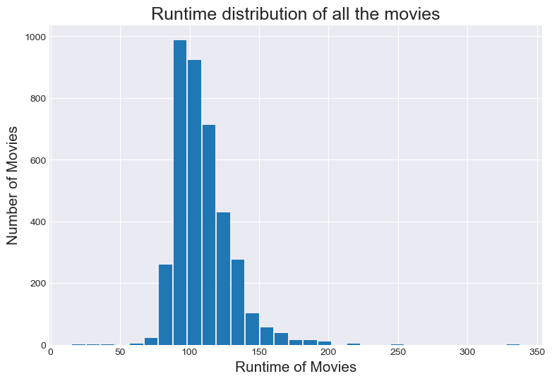

```python
#plotting a histogram of runtime of movies

#gives styles to bg plot
sns.set_style('darkgrid')

#chaging the label size, this will change the size of all plots that we plot from now!
plt.rc('xtick', labelsize = 10)
plt.rc('ytick', labelsize = 10)

#giving the figure size(width, height)
plt.figure(figsize=(9,6), dpi = 100)
#x-axis label name
plt.xlabel('Runtime of Movies', fontsize = 15)
#y-axis label name
plt.ylabel('Number of Movies', fontsize=15)
#title of the graph
plt.title('Runtime distribution of all the movies', fontsize=18)

#giving a histogram plot
plt.hist(movie_data['runtime'], rwidth = 0.9, bins =31)
#displays the plot
plt.show()
```

Above graph shows that how many movies lie between the time interval x1 to x2. For example, it can be seen that tallest bar is time interval between 85-100 min(approx) and around 1000 movies out of 3855 movies have the runtime between these time intervals. So we can say that mode time of movies is around 85-110 min, has the highest concentration of data points around this time interval. The distribution of this graph is positively skewed.

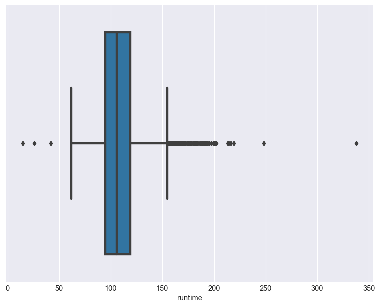

```python
#giving two plots, thr first is the box plot, second is plots of runtime for movies
#giving figure size
plt.figure(figsize=(9,7), dpi = 105)

#using seaborn to plot
#plotting box plot
sns.boxplot(movie_data['runtime'], linewidth = 3)
#showing the plot
plt.show()
```

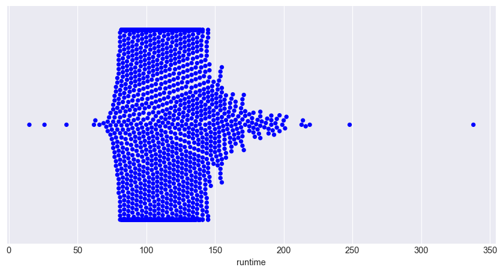

```python
#plots the data points of runtime of movies#plots t

#giving figure size
plt.figure(figsize=(10,5), dpi = 105)

sns.swarmplot(movie_data['runtime'], color = 'blue')
plt.show()
```

```python
#getting specific runtime points at x positions
movie_data['runtime'].describe()
```

```
count    3854.000000
mean      109.220291
std        19.922820
min        15.000000
25%        95.000000
50%       106.000000
75%       119.000000
max       338.000000
Name: runtime, dtype: float64
```

Both visualizations above shows us the overall distribution of runtime of movies by plotting the points where they lie in the ditribution and how many movies percent of movies lie below the runtime.

The box-plot shows that an overall idea of how spread the ditribution in our case the runtime of movies are. First of all we get the outliers from this visualization, the min and max points, the median and IQR.

### Research Question 2 (Detail Analysis)

#### How do budgets correlate with revenues? Do high budgets mean high revenues?

```python
# Explore the Budget and Revenue columns - find rows with zeros for budget and revenue

cols=['budget','revenue','release_date']

len(tmdb_data[(tmdb_data['budget']==0) | (tmdb_data['revenue']==0)])
```

```
7011
```

There are 7011 rows where budget or revenue is zero. For the purpose of this analysis, zeros are treated as missing values. Records that have missing / zero budget or revenue data are ignored and a subset of data with non zero budgets and revenues is used for the analysis.

```python
df=tmdb_data[(tmdb_data['budget']>0) & (tmdb_data['revenue']>0)]
df.shape
```

```
(3855, 21)
```

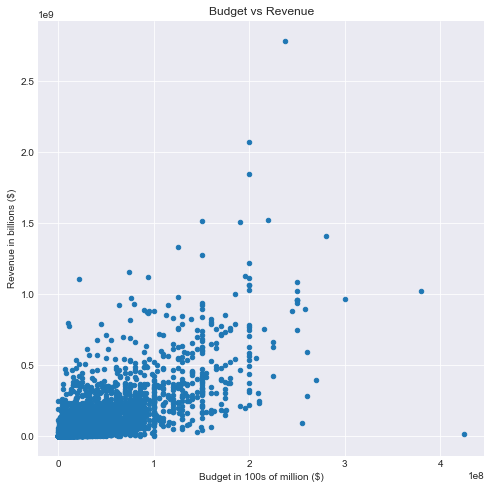

```python
df.plot(x='budget',y='revenue',kind='scatter',figsize=(8,8));
plt.title('Budget vs Revenue')
plt.xlabel('Budget in 100s of million ($)');
plt.ylabel('Revenue in billions ($)');
```

```python
#Pearson's correlation coefficient

def correlation_coeff(x,y):
    std_x=(x-x.mean())/x.std(ddof=0)
    std_y=(y-y.mean())/y.std(ddof=0)
    return(std_x*std_y).mean()

correlation_coeff(df['budget'],df['revenue'])
```

```
0.6885476775894028
```

From the uphill scatterplot and the value of 0.69 for the Pearson's coefficient we can infer that there is a positive relationship between budget and revenue. However , not a perfectly positive correlation. It can be seen from the plot that there are some movies with high budgets but low revenues and some with low budgets and high revenues. The outliers are more with high budget movies which get low/ moderate revenues.

#### How do ratings correlate with commercial success (profits)?

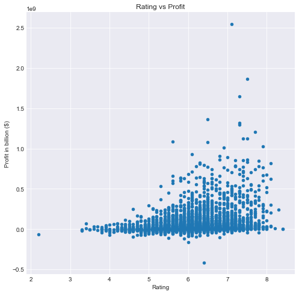

```python
df['Profit']=df['revenue']-df['budget']
df.plot(x='vote_average',y='Profit',kind='scatter',figsize=(8,8));
plt.ylabel('Profit in billion ($)');
plt.xlabel('Rating');
plt.title('Rating vs Profit');
```

```python
correlation_coeff(df['vote_average'],df['Profit'])
```

```
0.2595994929402839
```

The rating (vote_average) and profits appear to have a weak positive (uphill) relationship implying that a high rating does not strongly correlate to high profits.